# Risk Factor Analysis

## Outcome Variable

**Outcome Variable:** ever_stunted

## Predictor Variables

**Intervention Variable:** lag_WHZ_quart

**Adjustment Set:**

unadjusted

## Stratifying Variables

The analysis was stratified on these variable(s):

- agecat
- studyid
- country

## Data Summary

| agecat | studyid | country | lag_WHZ_quart | ever_stunted | n_cell | n |
| --- | --- | --- | --- | --- | --- | --- |
| 3-6 months | CMC-V-BCS-2002 | INDIA | 1 | 0 | 34 | 294 |
| 3-6 months | CMC-V-BCS-2002 | INDIA | 1 | 1 | 20 | 294 |
| 3-6 months | CMC-V-BCS-2002 | INDIA | 2 | 0 | 85 | 294 |
| 3-6 months | CMC-V-BCS-2002 | INDIA | 2 | 1 | 48 | 294 |
| 3-6 months | CMC-V-BCS-2002 | INDIA | 3 | 0 | 72 | 294 |
| 3-6 months | CMC-V-BCS-2002 | INDIA | 3 | 1 | 22 | 294 |
| 3-6 months | CMC-V-BCS-2002 | INDIA | 4 | 0 | 9 | 294 |
| 3-6 months | CMC-V-BCS-2002 | INDIA | 4 | 1 | 4 | 294 |
| 3-6 months | CMIN | BANGLADESH | 1 | 0 | 40 | 159 |
| 3-6 months | CMIN | BANGLADESH | 1 | 1 | 15 | 159 |
| 3-6 months | CMIN | BANGLADESH | 2 | 0 | 43 | 159 |
| 3-6 months | CMIN | BANGLADESH | 2 | 1 | 11 | 159 |
| 3-6 months | CMIN | BANGLADESH | 3 | 0 | 25 | 159 |
| 3-6 months | CMIN | BANGLADESH | 3 | 1 | 9 | 159 |
| 3-6 months | CMIN | BANGLADESH | 4 | 0 | 13 | 159 |
| 3-6 months | CMIN | BANGLADESH | 4 | 1 | 3 | 159 |
| 3-6 months | CONTENT | PERU | 1 | 0 | 0 | 4 |
| 3-6 months | CONTENT | PERU | 1 | 1 | 0 | 4 |
| 3-6 months | CONTENT | PERU | 2 | 0 | 1 | 4 |
| 3-6 months | CONTENT | PERU | 2 | 1 | 0 | 4 |
| 3-6 months | CONTENT | PERU | 3 | 0 | 3 | 4 |
| 3-6 months | CONTENT | PERU | 3 | 1 | 0 | 4 |
| 3-6 months | CONTENT | PERU | 4 | 0 | 0 | 4 |
| 3-6 months | CONTENT | PERU | 4 | 1 | 0 | 4 |
| 3-6 months | EE | PAKISTAN | 1 | 0 | 1 | 5 |
| 3-6 months | EE | PAKISTAN | 1 | 1 | 1 | 5 |
| 3-6 months | EE | PAKISTAN | 2 | 0 | 1 | 5 |
| 3-6 months | EE | PAKISTAN | 2 | 1 | 2 | 5 |
| 3-6 months | EE | PAKISTAN | 3 | 0 | 0 | 5 |
| 3-6 months | EE | PAKISTAN | 3 | 1 | 0 | 5 |

[output cut: 850 more lines]

The following strata were considered:

- agecat: 12-15 months, studyid: CMC-V-BCS-2002, country: INDIA
- agecat: 12-15 months, studyid: CMIN, country: BANGLADESH
- agecat: 12-15 months, studyid: EE, country: PAKISTAN
- agecat: 12-15 months, studyid: GMS-Nepal, country: NEPAL
- agecat: 12-15 months, studyid: Guatemala BSC, country: GUATEMALA
- agecat: 12-15 months, studyid: IRC, country: INDIA
- agecat: 12-15 months, studyid: Keneba, country: GAMBIA
- agecat: 12-15 months, studyid: MAL-ED, country: BRAZIL
- agecat: 12-15 months, studyid: MAL-ED, country: INDIA
- agecat: 12-15 months, studyid: MAL-ED, country: NEPAL
- agecat: 12-15 months, studyid: MAL-ED, country: PERU
- agecat: 12-15 months, studyid: MAL-ED, country: SOUTH AFRICA
- agecat: 12-15 months, studyid: MAL-ED, country: TANZANIA, UNITED REPUBLIC OF
- agecat: 12-15 months, studyid: PROVIDE, country: BANGLADESH
- agecat: 12-15 months, studyid: ResPak, country: PAKISTAN
- agecat: 12-15 months, studyid: TanzaniaChild2, country: TANZANIA, UNITED REPUBLIC OF
- agecat: 15-18 months, studyid: CMC-V-BCS-2002, country: INDIA
- agecat: 15-18 months, studyid: CMIN, country: BANGLADESH
- agecat: 15-18 months, studyid: CONTENT, country: PERU
- agecat: 15-18 months, studyid: EE, country: PAKISTAN
- agecat: 15-18 months, studyid: GMS-Nepal, country: NEPAL
- agecat: 15-18 months, studyid: Guatemala BSC, country: GUATEMALA
- agecat: 15-18 months, studyid: IRC, country: INDIA
- agecat: 15-18 months, studyid: Keneba, country: GAMBIA
- agecat: 15-18 months, studyid: MAL-ED, country: BRAZIL
- agecat: 15-18 months, studyid: MAL-ED, country: INDIA
- agecat: 15-18 months, studyid: MAL-ED, country: NEPAL
- agecat: 15-18 months, studyid: MAL-ED, country: PERU
- agecat: 15-18 months, studyid: MAL-ED, country: SOUTH AFRICA
- agecat: 15-18 months, studyid: MAL-ED, country: TANZANIA, UNITED REPUBLIC OF
- agecat: 15-18 months, studyid: PROVIDE, country: BANGLADESH
- agecat: 15-18 months, studyid: ResPak, country: PAKISTAN
- agecat: 15-18 months, studyid: TanzaniaChild2, country: TANZANIA, UNITED REPUBLIC OF
- agecat: 18-21 months, studyid: CMC-V-BCS-2002, country: INDIA
- agecat: 18-21 months, studyid: CMIN, country: BANGLADESH
- agecat: 18-21 months, studyid: EE, country: PAKISTAN
- agecat: 18-21 months, studyid: GMS-Nepal, country: NEPAL
- agecat: 18-21 months, studyid: IRC, country: INDIA
- agecat: 18-21 months, studyid: Keneba, country: GAMBIA
- agecat: 18-21 months, studyid: MAL-ED, country: BRAZIL
- agecat: 18-21 months, studyid: MAL-ED, country: INDIA
- agecat: 18-21 months, studyid: MAL-ED, country: NEPAL
- agecat: 18-21 months, studyid: MAL-ED, country: PERU
- agecat: 18-21 months, studyid: MAL-ED, country: SOUTH AFRICA
- agecat: 18-21 months, studyid: MAL-ED, country: TANZANIA, UNITED REPUBLIC OF
- agecat: 18-21 months, studyid: PROVIDE, country: BANGLADESH
- agecat: 18-21 months, studyid: TanzaniaChild2, country: TANZANIA, UNITED REPUBLIC OF
- agecat: 21-24 months, studyid: CMC-V-BCS-2002, country: INDIA
- agecat: 21-24 months, studyid: CMIN, country: BANGLADESH
- agecat: 21-24 months, studyid: GMS-Nepal, country: NEPAL
- agecat: 21-24 months, studyid: IRC, country: INDIA
- agecat: 21-24 months, studyid: Keneba, country: GAMBIA
- agecat: 21-24 months, studyid: MAL-ED, country: BRAZIL
- agecat: 21-24 months, studyid: MAL-ED, country: INDIA
- agecat: 21-24 months, studyid: MAL-ED, country: NEPAL
- agecat: 21-24 months, studyid: MAL-ED, country: PERU
- agecat: 21-24 months, studyid: MAL-ED, country: SOUTH AFRICA
- agecat: 21-24 months, studyid: MAL-ED, country: TANZANIA, UNITED REPUBLIC OF
- agecat: 21-24 months, studyid: PROVIDE, country: BANGLADESH
- agecat: 21-24 months, studyid: TanzaniaChild2, country: TANZANIA, UNITED REPUBLIC OF
- agecat: 3-6 months, studyid: CMC-V-BCS-2002, country: INDIA
- agecat: 3-6 months, studyid: CMIN, country: BANGLADESH
- agecat: 3-6 months, studyid: CONTENT, country: PERU
- agecat: 3-6 months, studyid: EE, country: PAKISTAN
- agecat: 3-6 months, studyid: GMS-Nepal, country: NEPAL
- agecat: 3-6 months, studyid: Guatemala BSC, country: GUATEMALA
- agecat: 3-6 months, studyid: IRC, country: INDIA
- agecat: 3-6 months, studyid: Keneba, country: GAMBIA
- agecat: 3-6 months, studyid: MAL-ED, country: INDIA
- agecat: 3-6 months, studyid: MAL-ED, country: NEPAL
- agecat: 3-6 months, studyid: MAL-ED, country: PERU
- agecat: 3-6 months, studyid: MAL-ED, country: SOUTH AFRICA
- agecat: 3-6 months, studyid: MAL-ED, country: TANZANIA, UNITED REPUBLIC OF
- agecat: 3-6 months, studyid: PROVIDE, country: BANGLADESH
- agecat: 3-6 months, studyid: ResPak, country: PAKISTAN
- agecat: 3-6 months, studyid: TanzaniaChild2, country: TANZANIA, UNITED REPUBLIC OF
- agecat: 6-9 months, studyid: CMC-V-BCS-2002, country: INDIA
- agecat: 6-9 months, studyid: CMIN, country: BANGLADESH
- agecat: 6-9 months, studyid: CONTENT, country: PERU
- agecat: 6-9 months, studyid: EE, country: PAKISTAN
- agecat: 6-9 months, studyid: GMS-Nepal, country: NEPAL
- agecat: 6-9 months, studyid: Guatemala BSC, country: GUATEMALA
- agecat: 6-9 months, studyid: IRC, country: INDIA
- agecat: 6-9 months, studyid: Keneba, country: GAMBIA
- agecat: 6-9 months, studyid: MAL-ED, country: BRAZIL
- agecat: 6-9 months, studyid: MAL-ED, country: INDIA
- agecat: 6-9 months, studyid: MAL-ED, country: NEPAL
- agecat: 6-9 months, studyid: MAL-ED, country: PERU
- agecat: 6-9 months, studyid: MAL-ED, country: SOUTH AFRICA
- agecat: 6-9 months, studyid: MAL-ED, country: TANZANIA, UNITED REPUBLIC OF
- agecat: 6-9 months, studyid: PROVIDE, country: BANGLADESH
- agecat: 6-9 months, studyid: ResPak, country: PAKISTAN
- agecat: 6-9 months, studyid: TanzaniaChild2, country: TANZANIA, UNITED REPUBLIC OF
- agecat: 9-12 months, studyid: CMC-V-BCS-2002, country: INDIA
- agecat: 9-12 months, studyid: CMIN, country: BANGLADESH
- agecat: 9-12 months, studyid: CONTENT, country: PERU
- agecat: 9-12 months, studyid: EE, country: PAKISTAN
- agecat: 9-12 months, studyid: GMS-Nepal, country: NEPAL
- agecat: 9-12 months, studyid: Guatemala BSC, country: GUATEMALA
- agecat: 9-12 months, studyid: IRC, country: INDIA
- agecat: 9-12 months, studyid: Keneba, country: GAMBIA
- agecat: 9-12 months, studyid: MAL-ED, country: BRAZIL
- agecat: 9-12 months, studyid: MAL-ED, country: INDIA
- agecat: 9-12 months, studyid: MAL-ED, country: NEPAL
- agecat: 9-12 months, studyid: MAL-ED, country: PERU
- agecat: 9-12 months, studyid: MAL-ED, country: SOUTH AFRICA
- agecat: 9-12 months, studyid: MAL-ED, country: TANZANIA, UNITED REPUBLIC OF
- agecat: 9-12 months, studyid: PROVIDE, country: BANGLADESH
- agecat: 9-12 months, studyid: ResPak, country: PAKISTAN
- agecat: 9-12 months, studyid: TanzaniaChild2, country: TANZANIA, UNITED REPUBLIC OF

### Dropped Strata

Some strata were dropped due to rare outcomes:

- agecat: 3-6 months, studyid: CMC-V-BCS-2002, country: INDIA
- agecat: 3-6 months, studyid: CMIN, country: BANGLADESH
- agecat: 3-6 months, studyid: CONTENT, country: PERU
- agecat: 3-6 months, studyid: EE, country: PAKISTAN
- agecat: 3-6 months, studyid: GMS-Nepal, country: NEPAL
- agecat: 3-6 months, studyid: Guatemala BSC, country: GUATEMALA
- agecat: 3-6 months, studyid: IRC, country: INDIA
- agecat: 3-6 months, studyid: MAL-ED, country: INDIA
- agecat: 3-6 months, studyid: MAL-ED, country: NEPAL
- agecat: 3-6 months, studyid: MAL-ED, country: PERU
- agecat: 3-6 months, studyid: MAL-ED, country: SOUTH AFRICA
- agecat: 3-6 months, studyid: MAL-ED, country: TANZANIA, UNITED REPUBLIC OF
- agecat: 6-9 months, studyid: CMC-V-BCS-2002, country: INDIA
- agecat: 6-9 months, studyid: CMIN, country: BANGLADESH
- agecat: 6-9 months, studyid: CONTENT, country: PERU
- agecat: 6-9 months, studyid: EE, country: PAKISTAN
- agecat: 6-9 months, studyid: GMS-Nepal, country: NEPAL
- agecat: 6-9 months, studyid: IRC, country: INDIA
- agecat: 6-9 months, studyid: MAL-ED, country: BRAZIL
- agecat: 6-9 months, studyid: MAL-ED, country: INDIA
- agecat: 6-9 months, studyid: MAL-ED, country: NEPAL
- agecat: 6-9 months, studyid: MAL-ED, country: PERU
- agecat: 6-9 months, studyid: MAL-ED, country: SOUTH AFRICA
- agecat: 6-9 months, studyid: MAL-ED, country: TANZANIA, UNITED REPUBLIC OF
- agecat: 6-9 months, studyid: PROVIDE, country: BANGLADESH
- agecat: 6-9 months, studyid: ResPak, country: PAKISTAN
- agecat: 9-12 months, studyid: CMC-V-BCS-2002, country: INDIA
- agecat: 9-12 months, studyid: CMIN, country: BANGLADESH
- agecat: 9-12 months, studyid: CONTENT, country: PERU
- agecat: 9-12 months, studyid: EE, country: PAKISTAN
- agecat: 9-12 months, studyid: GMS-Nepal, country: NEPAL
- agecat: 9-12 months, studyid: IRC, country: INDIA
- agecat: 9-12 months, studyid: MAL-ED, country: BRAZIL
- agecat: 9-12 months, studyid: MAL-ED, country: INDIA
- agecat: 9-12 months, studyid: MAL-ED, country: NEPAL
- agecat: 9-12 months, studyid: MAL-ED, country: PERU
- agecat: 9-12 months, studyid: MAL-ED, country: SOUTH AFRICA
- agecat: 9-12 months, studyid: MAL-ED, country: TANZANIA, UNITED REPUBLIC OF
- agecat: 9-12 months, studyid: PROVIDE, country: BANGLADESH
- agecat: 9-12 months, studyid: ResPak, country: PAKISTAN
- agecat: 12-15 months, studyid: CMC-V-BCS-2002, country: INDIA
- agecat: 12-15 months, studyid: CMIN, country: BANGLADESH
- agecat: 12-15 months, studyid: EE, country: PAKISTAN
- agecat: 12-15 months, studyid: GMS-Nepal, country: NEPAL
- agecat: 12-15 months, studyid: Guatemala BSC, country: GUATEMALA
- agecat: 12-15 months, studyid: IRC, country: INDIA
- agecat: 12-15 months, studyid: MAL-ED, country: BRAZIL
- agecat: 12-15 months, studyid: MAL-ED, country: INDIA
- agecat: 12-15 months, studyid: MAL-ED, country: NEPAL
- agecat: 12-15 months, studyid: MAL-ED, country: PERU
- agecat: 12-15 months, studyid: MAL-ED, country: SOUTH AFRICA
- agecat: 12-15 months, studyid: MAL-ED, country: TANZANIA, UNITED REPUBLIC OF
- agecat: 12-15 months, studyid: PROVIDE, country: BANGLADESH
- agecat: 12-15 months, studyid: ResPak, country: PAKISTAN
- agecat: 15-18 months, studyid: CMC-V-BCS-2002, country: INDIA
- agecat: 15-18 months, studyid: CMIN, country: BANGLADESH
- agecat: 15-18 months, studyid: CONTENT, country: PERU
- agecat: 15-18 months, studyid: EE, country: PAKISTAN
- agecat: 15-18 months, studyid: GMS-Nepal, country: NEPAL
- agecat: 15-18 months, studyid: Guatemala BSC, country: GUATEMALA
- agecat: 15-18 months, studyid: IRC, country: INDIA
- agecat: 15-18 months, studyid: MAL-ED, country: BRAZIL
- agecat: 15-18 months, studyid: MAL-ED, country: INDIA
- agecat: 15-18 months, studyid: MAL-ED, country: NEPAL
- agecat: 15-18 months, studyid: MAL-ED, country: PERU
- agecat: 15-18 months, studyid: MAL-ED, country: SOUTH AFRICA
- agecat: 15-18 months, studyid: MAL-ED, country: TANZANIA, UNITED REPUBLIC OF
- agecat: 15-18 months, studyid: PROVIDE, country: BANGLADESH
- agecat: 15-18 months, studyid: ResPak, country: PAKISTAN
- agecat: 18-21 months, studyid: CMC-V-BCS-2002, country: INDIA
- agecat: 18-21 months, studyid: CMIN, country: BANGLADESH
- agecat: 18-21 months, studyid: EE, country: PAKISTAN
- agecat: 18-21 months, studyid: GMS-Nepal, country: NEPAL
- agecat: 18-21 months, studyid: IRC, country: INDIA
- agecat: 18-21 months, studyid: MAL-ED, country: BRAZIL
- agecat: 18-21 months, studyid: MAL-ED, country: INDIA
- agecat: 18-21 months, studyid: MAL-ED, country: NEPAL
- agecat: 18-21 months, studyid: MAL-ED, country: PERU
- agecat: 18-21 months, studyid: MAL-ED, country: SOUTH AFRICA
- agecat: 18-21 months, studyid: MAL-ED, country: TANZANIA, UNITED REPUBLIC OF
- agecat: 18-21 months, studyid: PROVIDE, country: BANGLADESH
- agecat: 18-21 months, studyid: TanzaniaChild2, country: TANZANIA, UNITED REPUBLIC OF
- agecat: 21-24 months, studyid: CMC-V-BCS-2002, country: INDIA
- agecat: 21-24 months, studyid: CMIN, country: BANGLADESH
- agecat: 21-24 months, studyid: GMS-Nepal, country: NEPAL
- agecat: 21-24 months, studyid: IRC, country: INDIA
- agecat: 21-24 months, studyid: MAL-ED, country: BRAZIL
- agecat: 21-24 months, studyid: MAL-ED, country: INDIA
- agecat: 21-24 months, studyid: MAL-ED, country: NEPAL
- agecat: 21-24 months, studyid: MAL-ED, country: PERU
- agecat: 21-24 months, studyid: MAL-ED, country: SOUTH AFRICA
- agecat: 21-24 months, studyid: MAL-ED, country: TANZANIA, UNITED REPUBLIC OF
- agecat: 21-24 months, studyid: PROVIDE, country: BANGLADESH
- agecat: 21-24 months, studyid: TanzaniaChild2, country: TANZANIA, UNITED REPUBLIC OF

## Methods Detail

We’re interested in the causal parameters $E[Y_a]$ for all values of $a \in \mathcal{A}$. These parameters represent the mean outcome if, possibly contrary to fact, we intervened to set all units to have $A=a$. Under the randomization and positivity assumptions, these are identified by the statistical parameters $\psi_a=E_W[E_{Y|A,W}(Y|A=a,W)]$. In addition, we’re interested in the mean of $Y$, $E[Y]$ under no intervention (the observed mean). We will estimate these parameters by using SuperLearner to fit the relevant likelihood factors – $E_{Y|A,W}(Y|A=a,W)$ and $p(A=a|W)$, and then updating our likelihood fit using a joint TMLE.

For unadjusted analyses ($W=\{\}$), initial likelihoods were estimated using Lrnr_glm to estimate the simple $E(Y|A)$ and Lrnr_mean to estimate $p(A)$. For adjusted analyses, a small library containing Lrnr_glmnet, Lrnr_xgboost, and Lrnr_mean was used.

Having estimated these parameters, we will then use the delta method to estimate relative risks and attributable risks relative to a prespecified baseline level of $A$.

# Results Detail

## Results Plots

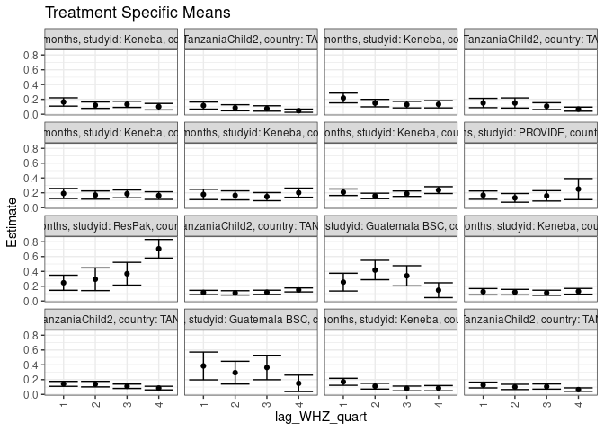

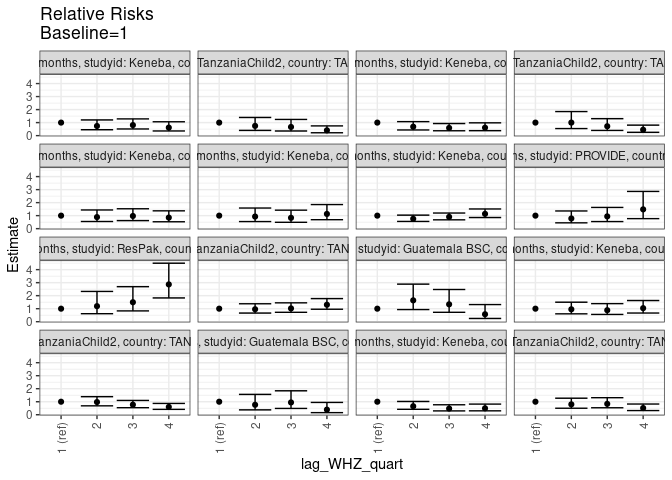

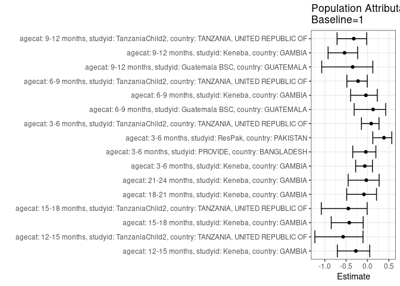

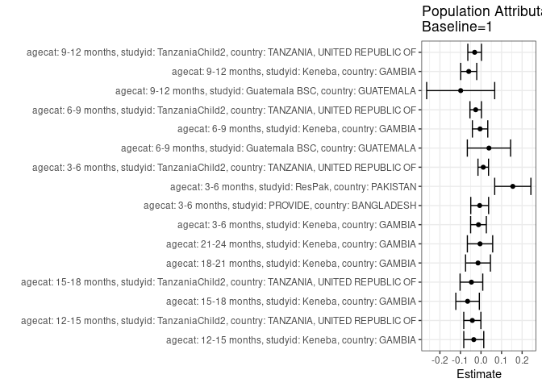

## Results Table

### Parameter: TSM

| agecat | studyid | country | intervention_level | baseline_level | estimate | ci_lower | ci_upper |
| --- | --- | --- | --- | --- | --- | --- | --- |
| 3-6 months | Keneba | GAMBIA | 1 | NA | 0.2078313 | 0.1641707 | 0.2514919 |
| 3-6 months | Keneba | GAMBIA | 2 | NA | 0.1577540 | 0.1207994 | 0.1947086 |
| 3-6 months | Keneba | GAMBIA | 3 | NA | 0.1879195 | 0.1516930 | 0.2241460 |
| 3-6 months | Keneba | GAMBIA | 4 | NA | 0.2363636 | 0.1905103 | 0.2822170 |
| 3-6 months | PROVIDE | BANGLADESH | 1 | NA | 0.1686047 | 0.1125887 | 0.2246206 |
| 3-6 months | PROVIDE | BANGLADESH | 2 | NA | 0.1317829 | 0.0733461 | 0.1902198 |
| 3-6 months | PROVIDE | BANGLADESH | 3 | NA | 0.1588785 | 0.0895347 | 0.2282223 |
| 3-6 months | PROVIDE | BANGLADESH | 4 | NA | 0.2500000 | 0.1083922 | 0.3916078 |
| 3-6 months | ResPak | PAKISTAN | 1 | NA | 0.2463768 | 0.1444392 | 0.3483144 |
| 3-6 months | ResPak | PAKISTAN | 2 | NA | 0.2941176 | 0.1405608 | 0.4476745 |
| 3-6 months | ResPak | PAKISTAN | 3 | NA | 0.3684211 | 0.2146494 | 0.5221927 |
| 3-6 months | ResPak | PAKISTAN | 4 | NA | 0.7058824 | 0.5805037 | 0.8312610 |
| 3-6 months | TanzaniaChild2 | TANZANIA, UNITED REPUBLIC OF | 1 | NA | 0.1148936 | 0.0860567 | 0.1437306 |
| 3-6 months | TanzaniaChild2 | TANZANIA, UNITED REPUBLIC OF | 2 | NA | 0.1098398 | 0.0805157 | 0.1391640 |
| 3-6 months | TanzaniaChild2 | TANZANIA, UNITED REPUBLIC OF | 3 | NA | 0.1174089 | 0.0890154 | 0.1458024 |
| 3-6 months | TanzaniaChild2 | TANZANIA, UNITED REPUBLIC OF | 4 | NA | 0.1497797 | 0.1229713 | 0.1765881 |
| 6-9 months | Guatemala BSC | GUATEMALA | 1 | NA | 0.2549020 | 0.1349964 | 0.3748075 |
| 6-9 months | Guatemala BSC | GUATEMALA | 2 | NA | 0.4181818 | 0.2874967 | 0.5488669 |
| 6-9 months | Guatemala BSC | GUATEMALA | 3 | NA | 0.3404255 | 0.2046176 | 0.4762335 |
| 6-9 months | Guatemala BSC | GUATEMALA | 4 | NA | 0.1458333 | 0.0457388 | 0.2459278 |
| 6-9 months | Keneba | GAMBIA | 1 | NA | 0.1260504 | 0.0838649 | 0.1682360 |
| 6-9 months | Keneba | GAMBIA | 2 | NA | 0.1200000 | 0.0832118 | 0.1567882 |
| 6-9 months | Keneba | GAMBIA | 3 | NA | 0.1111111 | 0.0768764 | 0.1453458 |
| 6-9 months | Keneba | GAMBIA | 4 | NA | 0.1310345 | 0.0921808 | 0.1698881 |
| 6-9 months | TanzaniaChild2 | TANZANIA, UNITED REPUBLIC OF | 1 | NA | 0.1431925 | 0.1099208 | 0.1764641 |
| 6-9 months | TanzaniaChild2 | TANZANIA, UNITED REPUBLIC OF | 2 | NA | 0.1393939 | 0.1020135 | 0.1767744 |
| 6-9 months | TanzaniaChild2 | TANZANIA, UNITED REPUBLIC OF | 3 | NA | 0.1105991 | 0.0810831 | 0.1401151 |
| 6-9 months | TanzaniaChild2 | TANZANIA, UNITED REPUBLIC OF | 4 | NA | 0.0858896 | 0.0610472 | 0.1107319 |
| 9-12 months | Guatemala BSC | GUATEMALA | 1 | NA | 0.3846154 | 0.1969056 | 0.5723252 |
| 9-12 months | Guatemala BSC | GUATEMALA | 2 | NA | 0.2941176 | 0.1403821 | 0.4478532 |
| 9-12 months | Guatemala BSC | GUATEMALA | 3 | NA | 0.3636364 | 0.1988898 | 0.5283829 |
| 9-12 months | Guatemala BSC | GUATEMALA | 4 | NA | 0.1500000 | 0.0389261 | 0.2610739 |
| 9-12 months | Keneba | GAMBIA | 1 | NA | 0.1707317 | 0.1236883 | 0.2177751 |
| 9-12 months | Keneba | GAMBIA | 2 | NA | 0.1115538 | 0.0725881 | 0.1505195 |
| 9-12 months | Keneba | GAMBIA | 3 | NA | 0.0809859 | 0.0492414 | 0.1127304 |
| 9-12 months | Keneba | GAMBIA | 4 | NA | 0.0843882 | 0.0489816 | 0.1197948 |
| 9-12 months | TanzaniaChild2 | TANZANIA, UNITED REPUBLIC OF | 1 | NA | 0.1272085 | 0.0883723 | 0.1660447 |
| 9-12 months | TanzaniaChild2 | TANZANIA, UNITED REPUBLIC OF | 2 | NA | 0.1014493 | 0.0658158 | 0.1370827 |
| 9-12 months | TanzaniaChild2 | TANZANIA, UNITED REPUBLIC OF | 3 | NA | 0.1063123 | 0.0714771 | 0.1411475 |
| 9-12 months | TanzaniaChild2 | TANZANIA, UNITED REPUBLIC OF | 4 | NA | 0.0654206 | 0.0419858 | 0.0888553 |
| 12-15 months | Keneba | GAMBIA | 1 | NA | 0.1647059 | 0.1089156 | 0.2204961 |
| 12-15 months | Keneba | GAMBIA | 2 | NA | 0.1216216 | 0.0786008 | 0.1646424 |
| 12-15 months | Keneba | GAMBIA | 3 | NA | 0.1333333 | 0.0915855 | 0.1750812 |
| 12-15 months | Keneba | GAMBIA | 4 | NA | 0.1016043 | 0.0582754 | 0.1449332 |
| 12-15 months | TanzaniaChild2 | TANZANIA, UNITED REPUBLIC OF | 1 | NA | 0.1162791 | 0.0683474 | 0.1642107 |
| 12-15 months | TanzaniaChild2 | TANZANIA, UNITED REPUBLIC OF | 2 | NA | 0.0869565 | 0.0462217 | 0.1276914 |
| 12-15 months | TanzaniaChild2 | TANZANIA, UNITED REPUBLIC OF | 3 | NA | 0.0772947 | 0.0408949 | 0.1136945 |
| 12-15 months | TanzaniaChild2 | TANZANIA, UNITED REPUBLIC OF | 4 | NA | 0.0471204 | 0.0258601 | 0.0683807 |
| 15-18 months | Keneba | GAMBIA | 1 | NA | 0.2185430 | 0.1525850 | 0.2845011 |
| 15-18 months | Keneba | GAMBIA | 2 | NA | 0.1494845 | 0.0992765 | 0.1996926 |
| 15-18 months | Keneba | GAMBIA | 3 | NA | 0.1288889 | 0.0850774 | 0.1727004 |
| 15-18 months | Keneba | GAMBIA | 4 | NA | 0.1336898 | 0.0848808 | 0.1824989 |
| 15-18 months | TanzaniaChild2 | TANZANIA, UNITED REPUBLIC OF | 1 | NA | 0.1507937 | 0.0882679 | 0.2133194 |
| 15-18 months | TanzaniaChild2 | TANZANIA, UNITED REPUBLIC OF | 2 | NA | 0.1509434 | 0.0827459 | 0.2191409 |
| 15-18 months | TanzaniaChild2 | TANZANIA, UNITED REPUBLIC OF | 3 | NA | 0.1085714 | 0.0624473 | 0.1546955 |
| 15-18 months | TanzaniaChild2 | TANZANIA, UNITED REPUBLIC OF | 4 | NA | 0.0681115 | 0.0406175 | 0.0956054 |
| 18-21 months | Keneba | GAMBIA | 1 | NA | 0.1908397 | 0.1235005 | 0.2581789 |
| 18-21 months | Keneba | GAMBIA | 2 | NA | 0.1694915 | 0.1141805 | 0.2248025 |
| 18-21 months | Keneba | GAMBIA | 3 | NA | 0.1857143 | 0.1330819 | 0.2383467 |
| 18-21 months | Keneba | GAMBIA | 4 | NA | 0.1624365 | 0.1108936 | 0.2139795 |
| 21-24 months | Keneba | GAMBIA | 1 | NA | 0.1779661 | 0.1088961 | 0.2470361 |
| 21-24 months | Keneba | GAMBIA | 2 | NA | 0.1655172 | 0.1049743 | 0.2260602 |
| 21-24 months | Keneba | GAMBIA | 3 | NA | 0.1481481 | 0.0933974 | 0.2028989 |
| 21-24 months | Keneba | GAMBIA | 4 | NA | 0.2012195 | 0.1398088 | 0.2626302 |

### Parameter: E(Y)

| agecat | studyid | country | intervention_level | baseline_level | estimate | ci_lower | ci_upper |
| --- | --- | --- | --- | --- | --- | --- | --- |
| 3-6 months | Keneba | GAMBIA | NA | NA | 0.1955496 | 0.1753565 | 0.2157426 |
| 3-6 months | PROVIDE | BANGLADESH | NA | NA | 0.1621622 | 0.1278379 | 0.1964864 |
| 3-6 months | ResPak | PAKISTAN | NA | NA | 0.4010417 | 0.3315353 | 0.4705480 |
| 3-6 months | TanzaniaChild2 | TANZANIA, UNITED REPUBLIC OF | NA | NA | 0.1258405 | 0.1115904 | 0.1400906 |
| 6-9 months | Guatemala BSC | GUATEMALA | NA | NA | 0.2935323 | 0.2304210 | 0.3566437 |
| 6-9 months | Keneba | GAMBIA | NA | NA | 0.1215278 | 0.1026517 | 0.1404039 |
| 6-9 months | TanzaniaChild2 | TANZANIA, UNITED REPUBLIC OF | NA | NA | 0.1173317 | 0.1019339 | 0.1327295 |
| 9-12 months | Guatemala BSC | GUATEMALA | NA | NA | 0.2857143 | 0.2086482 | 0.3627803 |
| 9-12 months | Keneba | GAMBIA | NA | NA | 0.1110020 | 0.0916955 | 0.1303085 |
| 9-12 months | TanzaniaChild2 | TANZANIA, UNITED REPUBLIC OF | NA | NA | 0.0962733 | 0.0801583 | 0.1123883 |
| 12-15 months | Keneba | GAMBIA | NA | NA | 0.1294964 | 0.1066961 | 0.1522967 |
| 12-15 months | TanzaniaChild2 | TANZANIA, UNITED REPUBLIC OF | NA | NA | 0.0740741 | 0.0573677 | 0.0907805 |
| 15-18 months | Keneba | GAMBIA | NA | NA | 0.1532365 | 0.1275592 | 0.1789138 |
| 15-18 months | TanzaniaChild2 | TANZANIA, UNITED REPUBLIC OF | NA | NA | 0.1041096 | 0.0819400 | 0.1262792 |
| 18-21 months | Keneba | GAMBIA | NA | NA | 0.1762238 | 0.1482767 | 0.2041708 |
| 21-24 months | Keneba | GAMBIA | NA | NA | 0.1731749 | 0.1425899 | 0.2037599 |

### Parameter: RR

| agecat | studyid | country | intervention_level | baseline_level | estimate | ci_lower | ci_upper |
| --- | --- | --- | --- | --- | --- | --- | --- |
| 3-6 months | Keneba | GAMBIA | 1 | 1 | 1.0000000 | 1.0000000 | 1.0000000 |
| 3-6 months | Keneba | GAMBIA | 2 | 1 | 0.7590483 | 0.5541363 | 1.0397339 |
| 3-6 months | Keneba | GAMBIA | 3 | 1 | 0.9041922 | 0.6798816 | 1.2025086 |
| 3-6 months | Keneba | GAMBIA | 4 | 1 | 1.1372859 | 0.8544445 | 1.5137546 |
| 3-6 months | PROVIDE | BANGLADESH | 1 | 1 | 1.0000000 | 1.0000000 | 1.0000000 |
| 3-6 months | PROVIDE | BANGLADESH | 2 | 1 | 0.7816092 | 0.4491106 | 1.3602728 |
| 3-6 months | PROVIDE | BANGLADESH | 3 | 1 | 0.9423139 | 0.5444730 | 1.6308532 |
| 3-6 months | PROVIDE | BANGLADESH | 4 | 1 | 1.4827586 | 0.7689177 | 2.8593087 |
| 3-6 months | ResPak | PAKISTAN | 1 | 1 | 1.0000000 | 1.0000000 | 1.0000000 |
| 3-6 months | ResPak | PAKISTAN | 2 | 1 | 1.1937716 | 0.6132140 | 2.3239698 |
| 3-6 months | ResPak | PAKISTAN | 3 | 1 | 1.4953560 | 0.8308244 | 2.6914108 |
| 3-6 months | ResPak | PAKISTAN | 4 | 1 | 2.8650519 | 1.8263605 | 4.4944700 |
| 3-6 months | TanzaniaChild2 | TANZANIA, UNITED REPUBLIC OF | 1 | 1 | 1.0000000 | 1.0000000 | 1.0000000 |
| 3-6 months | TanzaniaChild2 | TANZANIA, UNITED REPUBLIC OF | 2 | 1 | 0.9560132 | 0.6627144 | 1.3791178 |
| 3-6 months | TanzaniaChild2 | TANZANIA, UNITED REPUBLIC OF | 3 | 1 | 1.0218923 | 0.7211687 | 1.4480162 |
| 3-6 months | TanzaniaChild2 | TANZANIA, UNITED REPUBLIC OF | 4 | 1 | 1.3036384 | 0.9578044 | 1.7743426 |
| 6-9 months | Guatemala BSC | GUATEMALA | 1 | 1 | 1.0000000 | 1.0000000 | 1.0000000 |
| 6-9 months | Guatemala BSC | GUATEMALA | 2 | 1 | 1.6405594 | 0.9326671 | 2.8857406 |
| 6-9 months | Guatemala BSC | GUATEMALA | 3 | 1 | 1.3355155 | 0.7207460 | 2.4746606 |
| 6-9 months | Guatemala BSC | GUATEMALA | 4 | 1 | 0.5721154 | 0.2489505 | 1.3147835 |
| 6-9 months | Keneba | GAMBIA | 1 | 1 | 1.0000000 | 1.0000000 | 1.0000000 |
| 6-9 months | Keneba | GAMBIA | 2 | 1 | 0.9520000 | 0.6046832 | 1.4988079 |
| 6-9 months | Keneba | GAMBIA | 3 | 1 | 0.8814815 | 0.5593073 | 1.3892356 |
| 6-9 months | Keneba | GAMBIA | 4 | 1 | 1.0395402 | 0.6647445 | 1.6256530 |
| 6-9 months | TanzaniaChild2 | TANZANIA, UNITED REPUBLIC OF | 1 | 1 | 1.0000000 | 1.0000000 | 1.0000000 |
| 6-9 months | TanzaniaChild2 | TANZANIA, UNITED REPUBLIC OF | 2 | 1 | 0.9734724 | 0.6826919 | 1.3881058 |
| 6-9 months | TanzaniaChild2 | TANZANIA, UNITED REPUBLIC OF | 3 | 1 | 0.7723804 | 0.5421950 | 1.1002897 |
| 6-9 months | TanzaniaChild2 | TANZANIA, UNITED REPUBLIC OF | 4 | 1 | 0.5998190 | 0.4138982 | 0.8692543 |
| 9-12 months | Guatemala BSC | GUATEMALA | 1 | 1 | 1.0000000 | 1.0000000 | 1.0000000 |
| 9-12 months | Guatemala BSC | GUATEMALA | 2 | 1 | 0.7647059 | 0.3740412 | 1.5633977 |
| 9-12 months | Guatemala BSC | GUATEMALA | 3 | 1 | 0.9454545 | 0.4857766 | 1.8401139 |
| 9-12 months | Guatemala BSC | GUATEMALA | 4 | 1 | 0.3900000 | 0.1606597 | 0.9467217 |
| 9-12 months | Keneba | GAMBIA | 1 | 1 | 1.0000000 | 1.0000000 | 1.0000000 |
| 9-12 months | Keneba | GAMBIA | 2 | 1 | 0.6533865 | 0.4187495 | 1.0194971 |
| 9-12 months | Keneba | GAMBIA | 3 | 1 | 0.4743461 | 0.2937726 | 0.7659129 |
| 9-12 months | Keneba | GAMBIA | 4 | 1 | 0.4942737 | 0.2992064 | 0.8165147 |
| 9-12 months | TanzaniaChild2 | TANZANIA, UNITED REPUBLIC OF | 1 | 1 | 1.0000000 | 1.0000000 | 1.0000000 |
| 9-12 months | TanzaniaChild2 | TANZANIA, UNITED REPUBLIC OF | 2 | 1 | 0.7975040 | 0.5007503 | 1.2701194 |
| 9-12 months | TanzaniaChild2 | TANZANIA, UNITED REPUBLIC OF | 3 | 1 | 0.8357327 | 0.5340322 | 1.3078785 |
| 9-12 months | TanzaniaChild2 | TANZANIA, UNITED REPUBLIC OF | 4 | 1 | 0.5142783 | 0.3212117 | 0.8233889 |
| 12-15 months | Keneba | GAMBIA | 1 | 1 | 1.0000000 | 1.0000000 | 1.0000000 |
| 12-15 months | Keneba | GAMBIA | 2 | 1 | 0.7384170 | 0.4524854 | 1.2050325 |
| 12-15 months | Keneba | GAMBIA | 3 | 1 | 0.8095238 | 0.5103890 | 1.2839791 |
| 12-15 months | Keneba | GAMBIA | 4 | 1 | 0.6168831 | 0.3578364 | 1.0634603 |
| 12-15 months | TanzaniaChild2 | TANZANIA, UNITED REPUBLIC OF | 1 | 1 | 1.0000000 | 1.0000000 | 1.0000000 |
| 12-15 months | TanzaniaChild2 | TANZANIA, UNITED REPUBLIC OF | 2 | 1 | 0.7478261 | 0.4006866 | 1.3957139 |
| 12-15 months | TanzaniaChild2 | TANZANIA, UNITED REPUBLIC OF | 3 | 1 | 0.6647343 | 0.3555047 | 1.2429418 |
| 12-15 months | TanzaniaChild2 | TANZANIA, UNITED REPUBLIC OF | 4 | 1 | 0.4052356 | 0.2199342 | 0.7466592 |
| 15-18 months | Keneba | GAMBIA | 1 | 1 | 1.0000000 | 1.0000000 | 1.0000000 |
| 15-18 months | Keneba | GAMBIA | 2 | 1 | 0.6840050 | 0.4354642 | 1.0744003 |
| 15-18 months | Keneba | GAMBIA | 3 | 1 | 0.5897643 | 0.3743366 | 0.9291689 |
| 15-18 months | Keneba | GAMBIA | 4 | 1 | 0.6117323 | 0.3809268 | 0.9823841 |
| 15-18 months | TanzaniaChild2 | TANZANIA, UNITED REPUBLIC OF | 1 | 1 | 1.0000000 | 1.0000000 | 1.0000000 |
| 15-18 months | TanzaniaChild2 | TANZANIA, UNITED REPUBLIC OF | 2 | 1 | 1.0009930 | 0.5421324 | 1.8482333 |
| 15-18 months | TanzaniaChild2 | TANZANIA, UNITED REPUBLIC OF | 3 | 1 | 0.7200000 | 0.3976657 | 1.3036075 |
| 15-18 months | TanzaniaChild2 | TANZANIA, UNITED REPUBLIC OF | 4 | 1 | 0.4516865 | 0.2532323 | 0.8056661 |
| 18-21 months | Keneba | GAMBIA | 1 | 1 | 1.0000000 | 1.0000000 | 1.0000000 |
| 18-21 months | Keneba | GAMBIA | 2 | 1 | 0.8881356 | 0.5492188 | 1.4361941 |
| 18-21 months | Keneba | GAMBIA | 3 | 1 | 0.9731429 | 0.6189056 | 1.5301316 |
| 18-21 months | Keneba | GAMBIA | 4 | 1 | 0.8511675 | 0.5295681 | 1.3680698 |
| 21-24 months | Keneba | GAMBIA | 1 | 1 | 1.0000000 | 1.0000000 | 1.0000000 |
| 21-24 months | Keneba | GAMBIA | 2 | 1 | 0.9300493 | 0.5456210 | 1.5853342 |
| 21-24 months | Keneba | GAMBIA | 3 | 1 | 0.8324515 | 0.4870942 | 1.4226726 |
| 21-24 months | Keneba | GAMBIA | 4 | 1 | 1.1306620 | 0.6900940 | 1.8524963 |

### Parameter: PAR

| agecat | studyid | country | intervention_level | baseline_level | estimate | ci_lower | ci_upper |
| --- | --- | --- | --- | --- | --- | --- | --- |
| 3-6 months | Keneba | GAMBIA | 1 | NA | -0.0122818 | -0.0504983 | 0.0259348 |
| 3-6 months | PROVIDE | BANGLADESH | 1 | NA | -0.0064425 | -0.0498575 | 0.0369725 |
| 3-6 months | ResPak | PAKISTAN | 1 | NA | 0.1546649 | 0.0666099 | 0.2427198 |
| 3-6 months | TanzaniaChild2 | TANZANIA, UNITED REPUBLIC OF | 1 | NA | 0.0109469 | -0.0147278 | 0.0366216 |
| 6-9 months | Guatemala BSC | GUATEMALA | 1 | NA | 0.0386304 | -0.0665572 | 0.1438179 |
| 6-9 months | Keneba | GAMBIA | 1 | NA | -0.0045226 | -0.0419472 | 0.0329019 |
| 6-9 months | TanzaniaChild2 | TANZANIA, UNITED REPUBLIC OF | 1 | NA | -0.0258607 | -0.0538313 | 0.0021098 |
| 9-12 months | Guatemala BSC | GUATEMALA | 1 | NA | -0.0989011 | -0.2644247 | 0.0666225 |
| 9-12 months | Keneba | GAMBIA | 1 | NA | -0.0597297 | -0.0986686 | -0.0207908 |
| 9-12 months | TanzaniaChild2 | TANZANIA, UNITED REPUBLIC OF | 1 | NA | -0.0309352 | -0.0641791 | 0.0023087 |
| 12-15 months | Keneba | GAMBIA | 1 | NA | -0.0352095 | -0.0838253 | 0.0134063 |
| 12-15 months | TanzaniaChild2 | TANZANIA, UNITED REPUBLIC OF | 1 | NA | -0.0422050 | -0.0839210 | -0.0004890 |
| 15-18 months | Keneba | GAMBIA | 1 | NA | -0.0653066 | -0.1225272 | -0.0080860 |
| 15-18 months | TanzaniaChild2 | TANZANIA, UNITED REPUBLIC OF | 1 | NA | -0.0466841 | -0.1019234 | 0.0085553 |
| 18-21 months | Keneba | GAMBIA | 1 | NA | -0.0146159 | -0.0750641 | 0.0458323 |
| 21-24 months | Keneba | GAMBIA | 1 | NA | -0.0047912 | -0.0663916 | 0.0568091 |

### Parameter: PAF

| agecat | studyid | country | intervention_level | baseline_level | estimate | ci_lower | ci_upper |
| --- | --- | --- | --- | --- | --- | --- | --- |
| 3-6 months | Keneba | GAMBIA | 1 | NA | -0.0628064 | -0.2772974 | 0.1156660 |
| 3-6 months | PROVIDE | BANGLADESH | 1 | NA | -0.0397287 | -0.3449809 | 0.1962446 |
| 3-6 months | ResPak | PAKISTAN | 1 | NA | 0.3856578 | 0.1243179 | 0.5690031 |
| 3-6 months | TanzaniaChild2 | TANZANIA, UNITED REPUBLIC OF | 1 | NA | 0.0869904 | -0.1414096 | 0.2696868 |
| 6-9 months | Guatemala BSC | GUATEMALA | 1 | NA | 0.1316052 | -0.3115264 | 0.4250138 |
| 6-9 months | Keneba | GAMBIA | 1 | NA | -0.0372149 | -0.3957101 | 0.2291990 |
| 6-9 months | TanzaniaChild2 | TANZANIA, UNITED REPUBLIC OF | 1 | NA | -0.2204070 | -0.4822276 | -0.0048345 |
| 9-12 months | Guatemala BSC | GUATEMALA | 1 | NA | -0.3461538 | -1.0710229 | 0.1250072 |
| 9-12 months | Keneba | GAMBIA | 1 | NA | -0.5380963 | -0.9223739 | -0.2306348 |
| 9-12 months | TanzaniaChild2 | TANZANIA, UNITED REPUBLIC OF | 1 | NA | -0.3213268 | -0.7120348 | -0.0197833 |
| 12-15 months | Keneba | GAMBIA | 1 | NA | -0.2718954 | -0.7060493 | 0.0517753 |
| 12-15 months | TanzaniaChild2 | TANZANIA, UNITED REPUBLIC OF | 1 | NA | -0.5697674 | -1.2313841 | -0.1043235 |
| 15-18 months | Keneba | GAMBIA | 1 | NA | -0.4261818 | -0.8487348 | -0.1002089 |
| 15-18 months | TanzaniaChild2 | TANZANIA, UNITED REPUBLIC OF | 1 | NA | -0.4484127 | -1.0809735 | -0.0081336 |
| 18-21 months | Keneba | GAMBIA | 1 | NA | -0.0829395 | -0.4863194 | 0.2109650 |
| 21-24 months | Keneba | GAMBIA | 1 | NA | -0.0276670 | -0.4526768 | 0.2729976 |